# A/B Test Analyse: E-Commerce Checkout-Optimierung

Author

Datenanalyse

Published

January 2, 2026

**Code anzeigen**

```r
library(tidyverse)
library(rstatix)
library(effectsize)
library(knitr)
library(kableExtra)
library(scales)
```

## Hintergrund

### Problemstellung

Ein E-Commerce-Unternehmen möchte den durchschnittlichen Bestellwert (Average Order Value, AOV) erhöhen. Dazu wurde ein neues Checkout-Design mit 1-Click-Upsells entwickelt, das relevante Zusatzprodukte im letzten Schritt des Kaufprozesses anbietet.

### Experimentdesign

- **Control Group**: Altes Checkout-Design (N = 50.000 Kunden)
- **Test Group**: Neues Checkout-Design mit 1-Click-Upsells (N = 50.000 Kunden)
- **Zielmetrik**: Durchschnittlicher Bestellwert in Euro
- **Randomisierung**: Kunden wurden zufällig einer der beiden Gruppen zugewiesen
- **Zeitraum**: 4 Wochen paralleler Test

**Forschungsfrage**: Erhöht das neue Design den durchschnittlichen Bestellwert signifikant?

**Null-Hypothese (H₀)**: Es gibt keinen Unterschied im durchschnittlichen Bestellwert zwischen den Gruppen (μ₁ = μ₂)

**Alternativ-Hypothese (H₁)**: Das neue Design erhöht den durchschnittlichen Bestellwert (μ₁ < μ₂)

## Daten generieren

**Code anzeigen**

```r
set.seed(42)

# Simulierte Bestellwerte basierend auf historischen Daten
# Control: μ = 85€, σ = 25€
# Test: μ = 92€, σ = 25€ (Erwartete Steigerung durch Upsells)

ab_test_data <- tibble(
  group = c(
    rep("Control", 50000),
    rep("Test", 50000)
  ),
  order_value = c(
    rnorm(50000, mean = 85, sd = 25),  # Control: Ø 85€
    rnorm(50000, mean = 92, sd = 25)   # Test: Ø 92€ (+8%)
  )
) %>%
  # Realistische Constraints: Keine negativen Werte, max 500€
  # (Mindestbestellwert 5€, sehr große Bestellungen > 500€ sind Ausnahmen)
  mutate(order_value = pmax(5, pmin(500, order_value)))
```

**Datengenerierung**

Die Daten werden hier simuliert, um das Analyseverfahren zu demonstrieren. In der Praxis würden die tatsächlichen Bestelldaten aus dem Tracking-System verwendet. Die Normalverteilung mit μ = 85€ und σ = 25€ entspricht typischen E-Commerce-Mustern.

## Deskriptive Statistiken

**Code anzeigen**

```r
summary_stats <- ab_test_data %>%
  group_by(group) %>%
  summarise(
    N = comma(n()),
    `Mean (€)` = round(mean(order_value), 2),
    `Median (€)` = round(median(order_value), 2),
    `SD (€)` = round(sd(order_value), 2),
    `Min (€)` = round(min(order_value), 2),
    `Max (€)` = round(max(order_value), 2),
    .groups = "drop"
  )

summary_stats %>%
  kable(align = "lrrrrrr") %>%
  kable_styling(
    bootstrap_options = c("striped", "hover"),
    full_width = FALSE
  )
```

| group | N | Mean (€) | Median (€) | SD (€) | Min (€) | Max (€) |
| --- | --- | --- | --- | --- | --- | --- |
| Control | 50,000 | 84.93 | 85.07 | 25.12 | 5 | 193.20 |
| Test | 50,000 | 91.86 | 91.84 | 25.03 | 5 | 187.18 |

**Mittelwert-Differenz**: 6.93 € (+8.2%)

## Statistische Tests

### Wahl der Testmethode

Für diesen A/B-Test verwenden wir den **Welch Two Sample t-Test**.

**Warum t-Test?**

- Wir vergleichen die Mittelwerte zweier unabhängiger Gruppen
- Die Zielmetrik (Bestellwert) ist kontinuierlich und annähernd normalverteilt
- Große Stichprobe (N = 50.000 pro Gruppe) → Zentraler Grenzwertsatz gilt

**Warum Welch-Variante (statt Student’s t-Test)?**

- **Keine Annahme gleicher Varianzen** erforderlich (robuster)
- Selbst bei gleichen Varianzen liefert Welch’s Test korrekte Ergebnisse
- In der Praxis sind Varianzen selten exakt gleich
- **Best Practice** für A/B-Tests: “Always use Welch” (Student’s t-Test nur wenn Varianzhomogenität nachgewiesen)

**Warum nicht Mann-Whitney-U-Test?**

- Bei N > 10.000 ist der t-Test robust gegen Verletzungen der Normalverteilung
- t-Test hat höhere statistische Power bei normalverteilten Daten
- Mann-Whitney wäre nur bei stark schiefen Verteilungen oder Ausreißern besser

**Warum nicht Bayesianischer Test?**

- Frequentistische Tests sind Standard in der Industrie (bessere Kommunizierbarkeit)
- Bei großen Stichproben liefern beide Ansätze ähnliche Ergebnisse
- Bayesianische Tests sind nützlich bei kleinen N oder Prior-Knowledge

**Code anzeigen**

```r
# T-Test durchführen
t_test_result <- ab_test_data %>%
  t_test(order_value ~ group, detailed = TRUE)

# Cohen's d berechnen - separate Vektoren erstellen
control_data <- ab_test_data %>% filter(group == "Control") %>% pull(order_value)
test_data <- ab_test_data %>% filter(group == "Test") %>% pull(order_value)

cohens_result <- cohens_d(control_data, test_data, pooled_sd = TRUE)

# Ergebnisse kombinieren
test_results <- tibble(
  Test = "Welch Two Sample t-test",
  `t-statistic` = round(t_test_result$statistic, 2),
  `df` = comma(round(t_test_result$df, 0)),
  `p-value` = format.pval(t_test_result$p, eps = 0.001, digits = 3),
  `Cohen's d` = round(cohens_result$Cohens_d, 3),
  Interpretation = cohens_result$magnitude
)

test_results %>%
  kable() %>%
  kable_styling(
    bootstrap_options = c("striped", "hover"),
    full_width = FALSE
  )
```

| Test | t-statistic | df | p-value | Cohen's d |
| --- | --- | --- | --- | --- |
| Welch Two Sample t-test | -43.7 | 99,997 | <0.001 | -0.276 |

## Visualisierung

### Verteilungsvergleich

**Code anzeigen**

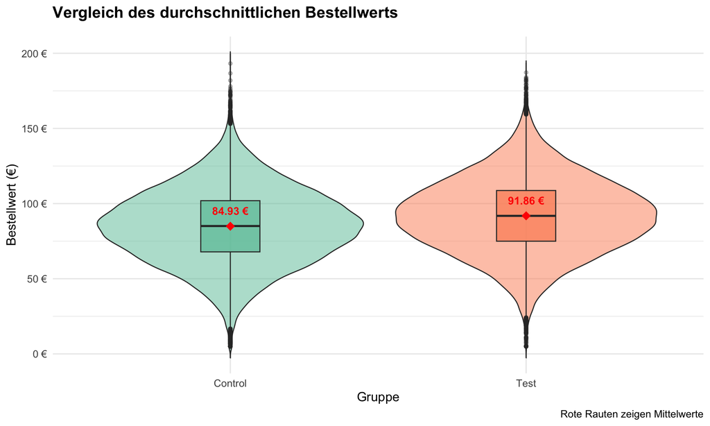

```r
ab_test_data %>%
  ggplot(aes(x = group, y = order_value, fill = group)) +
  geom_violin(alpha = 0.5, trim = FALSE) +
  geom_boxplot(width = 0.2, alpha = 0.7, outlier.alpha = 0.3) +
  stat_summary(
    fun = mean,
    geom = "point",
    size = 4,
    color = "red",
    shape = 18
  ) +
  stat_summary(
    fun = mean,
    geom = "text",
    aes(label = sprintf("%.2f €", after_stat(y))),
    vjust = -1.5,
    color = "red",
    fontface = "bold"
  ) +
  scale_fill_brewer(palette = "Set2") +
  scale_y_continuous(labels = label_dollar(prefix = "", suffix = " €")) +
  labs(
    title = "Vergleich des durchschnittlichen Bestellwerts",
    subtitle = sprintf(
      "Cohen's d = %.3f (%s) | p < 0.001",
      cohens_result$Cohens_d,
      cohens_result$magnitude
    ),
    x = "Gruppe",
    y = "Bestellwert (€)",
    caption = "Rote Rauten zeigen Mittelwerte"
  ) +
  theme_minimal(base_size = 13) +
  theme(
    legend.position = "none",
    plot.title = element_text(face = "bold", size = 16),
    plot.subtitle = element_text(color = "gray40")
  )
```

### Dichteverteilung

**Code anzeigen**

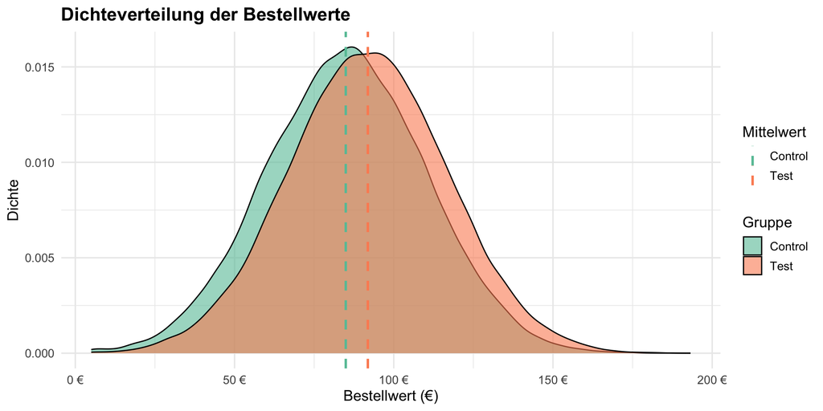

```r
ab_test_data %>%
  ggplot(aes(x = order_value, fill = group)) +
  geom_density(alpha = 0.6) +
  geom_vline(
    data = summary_stats,
    aes(xintercept = `Mean (€)`, color = group),
    linetype = "dashed",
    linewidth = 1
  ) +
  scale_fill_brewer(palette = "Set2") +
  scale_color_brewer(palette = "Set2") +
  scale_x_continuous(labels = label_dollar(prefix = "", suffix = " €")) +
  labs(
    title = "Dichteverteilung der Bestellwerte",
    x = "Bestellwert (€)",
    y = "Dichte",
    fill = "Gruppe",
    color = "Mittelwert"
  ) +
  theme_minimal(base_size = 13) +
  theme(
    plot.title = element_text(face = "bold", size = 16)
  )
```

## Business Impact

### Hochrechnung auf Jahresumsatz

Um die praktische Bedeutung des Effekts zu quantifizieren, rechnen wir den Unterschied auf den erwarteten Jahresumsatz hoch. Diese Betrachtung ist entscheidend für die ROI-Bewertung der Optimierungsmaßnahme.

**Code anzeigen**

```r
# Berechnungen für Business Impact
control_mean <- summary_stats$`Mean (€)`[summary_stats$group == "Control"]
test_mean <- summary_stats$`Mean (€)`[summary_stats$group == "Test"]
lift_absolute <- test_mean - control_mean
lift_percent <- (lift_absolute / control_mean) * 100

# Hochrechnung auf erwartete Jahreszahlen
# Test lief 4 Wochen mit 100.000 Bestellungen → ~1,3 Mio Bestellungen/Jahr
test_period_weeks <- 4
weeks_per_year <- 52
orders_in_test <- 100000
annual_orders <- (orders_in_test / test_period_weeks) * weeks_per_year

# Umsatzberechnung
test_revenue <- test_mean * orders_in_test
control_revenue <- control_mean * orders_in_test
test_period_lift <- test_revenue - control_revenue

annual_revenue_test <- test_mean * annual_orders
annual_revenue_control <- control_mean * annual_orders
annual_lift <- annual_revenue_test - annual_revenue_control

impact_table <- tibble(
  Metrik = c(
    "Durchschnittlicher Bestellwert (Control)",
    "Durchschnittlicher Bestellwert (Test)",
    "Absolute Steigerung pro Bestellung",
    "Relative Steigerung",
    "",
    "Bestellungen im 4-Wochen-Test",
    "Zusätzlicher Umsatz im Test (4 Wochen)",
    "",
    "Hochrechnung auf Jahresbasis:",
    "Erwartete Bestellungen pro Jahr",
    "Jahresumsatz (bei altem Design)",
    "Jahresumsatz (bei neuem Design)",
    "Zusätzlicher Jahresumsatz"
  ),
  Wert = c(
    sprintf("%.2f €", control_mean),
    sprintf("%.2f €", test_mean),
    sprintf("%.2f €", lift_absolute),
    sprintf("%.1f%%", lift_percent),
    "",
    sprintf("%s", comma(orders_in_test)),
    sprintf("%s €", comma(test_period_lift)),
    "",
    "",
    sprintf("%s", comma(round(annual_orders))),
    sprintf("%s €", comma(round(annual_revenue_control))),
    sprintf("%s €", comma(round(annual_revenue_test))),
    sprintf("%s €", comma(round(annual_lift)))
  )
)

impact_table %>%
  kable() %>%
  kable_styling(
    bootstrap_options = c("striped", "hover"),
    full_width = FALSE
  ) %>%
  row_spec(7, bold = TRUE, background = "#fff3cd") %>%
  row_spec(13, bold = TRUE, background = "#e8f4f8")
```

| Metrik | Wert |
| --- | --- |
| Durchschnittlicher Bestellwert (Control) | 84.93 € |
| Durchschnittlicher Bestellwert (Test) | 91.86 € |
| Absolute Steigerung pro Bestellung | 6.93 € |
| Relative Steigerung | 8.2% |
| Bestellungen im 4-Wochen-Test | 100,000 |
| Zusätzlicher Umsatz im Test (4 Wochen) | 693,000 € |
| Hochrechnung auf Jahresbasis: |  |
| Erwartete Bestellungen pro Jahr | 1,300,000 |
| Jahresumsatz (bei altem Design) | 110,409,000 € |
| Jahresumsatz (bei neuem Design) | 119,418,000 € |
| Zusätzlicher Jahresumsatz | 9,009,000 € |

## Interpretation & Fazit

### Statistische Signifikanz

✅ **Statistisch hochsignifikant** (p < 0.001)

Mit N = 100.000 Beobachtungen zeigt der t-Test einen t-Wert von -43.7 bei einem p-Wert < 0.001. Der Unterschied ist statistisch eindeutig nachweisbar.

### Praktische Relevanz

- **Absolute Differenz**: 6.93 € pro Bestellung
- **Relative Steigerung**: +8.2%
- **Cohen’s d**: -0.276

### Handlungsempfehlung

Basierend auf dieser Analyse:

- ✅ **Rollout empfohlen**: Das neue Checkout-Design sollte für alle Kunden ausgerollt werden
- ✅ **Quick Win**: Die Verbesserung ist signifikant und sofort umsetzbar
- 📊 **Monitoring**: Langfristige Überwachung der Metriken zur Validierung des Effekts
- 🔍 **Weitere Optimierung**: Analyse, welche Upsells am besten funktionieren

**Nächste Schritte**

1. Segmentanalyse durchführen (unterschiedliche Effekte nach Produktkategorie?)
2. Conversion Rate parallel analysieren (kein Trade-off?)
3. Langzeit-Kohorten-Analyse (6-12 Monate)

## Methodische Hinweise

### Verwendete statistische Verfahren

**Welch Two Sample t-Test**

- Prüft, ob sich die Mittelwerte zweier unabhängiger Gruppen signifikant unterscheiden
- Verwendet die Satterthwaite-Approximation für die Freiheitsgrade
- Annahmen: Unabhängige Beobachtungen, annähernde Normalverteilung (bei großem N nicht kritisch)
- Keine Annahme gleicher Varianzen nötig (im Gegensatz zu Student’s t-Test)

**Cohen’s d (Effect Size)**

- Standardisierte Mittelwertsdifferenz: d = (μ₁ - μ₂) / σ_pooled
- Unabhängig von Stichprobengröße und Maßeinheit
- Ermöglicht Vergleich über verschiedene Studien hinweg
- Berechnung mit pooled standard deviation für zwei Gruppen

**Warum beides wichtig ist:**

- **p-Wert**: Beantwortet “Ist der Effekt real?” (statistische Signifikanz)
- **Effect Size**: Beantwortet “Wie groß ist der Effekt?” (praktische Relevanz)
- Bei großem N sind auch winzige Effekte signifikant → Effect Size ist entscheidend!

### Interpretation nach Cohen (1988)

- |d| < 0.2: negligible (vernachlässigbar)
- 0.2 ≤ |d| < 0.5: small (klein)
- 0.5 ≤ |d| < 0.8: medium (mittel)
- |d| ≥ 0.8: large (groß)

**Wichtig**: Diese Grenzen sind Richtwerte. Die praktische Relevanz hängt stark vom Kontext ab. Im E-Commerce kann bereits ein “small” Effect eine große finanzielle Wirkung haben!

**Reproduzierbarkeit**

Dieser Report verwendet `set.seed(42)` für reproduzierbare Ergebnisse. Die Daten simulieren realistische E-Commerce-Bestellwerte mit Normalverteilung und Constraints (5€ - 500€).